# practical_machine_learning_project

Hyder Ali

2025-01-22

# Introduction

In this project, the goal is to predict the manner in which barbell lifts were performed based on accelerometer data. We will use a Random Forest model to classify the “classe” variable and evaluate the model’s performance.

# Data Overview

The data includes accelerometer readings from sensors on the belt, forearm, arm, and dumbbell of 6 participants performing barbell lifts in five different ways. The training dataset is used to build the model, and the test dataset is used for predictions.

```
## [1] 19622   160
```

```
## [1]  20 160
```

# Data Cleaning

In this section, we remove columns with excessive missing values and irrelevant columns like timestamps and identifiers.

# Exploratory Data Analysis

Here, we visualize the distribution of the target variable classe.

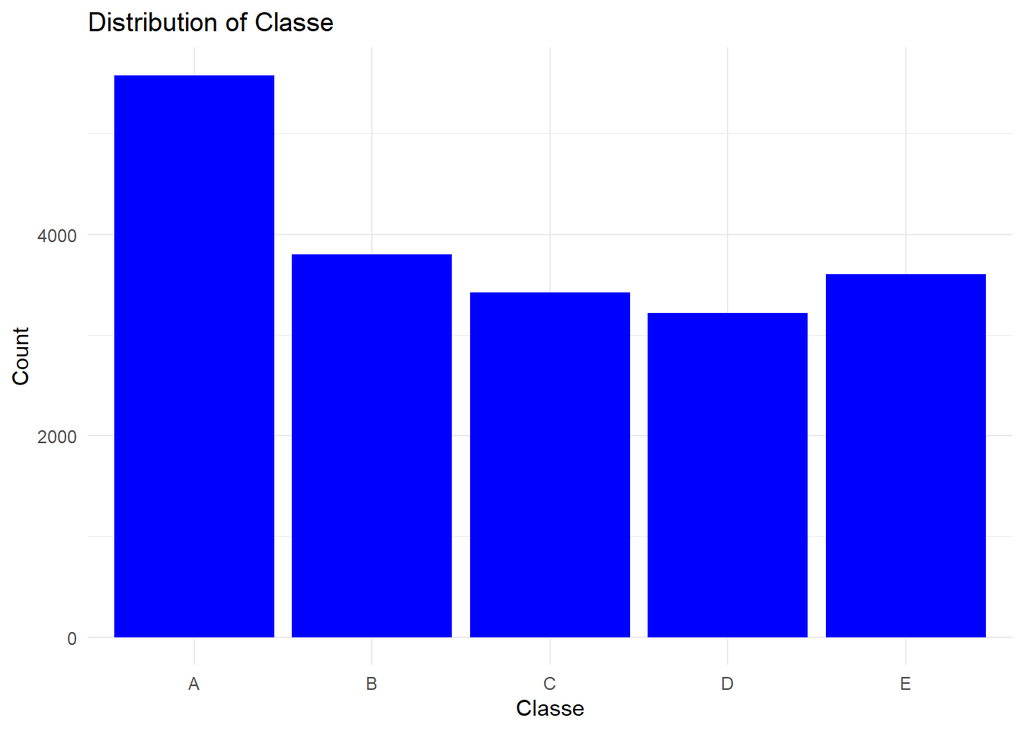

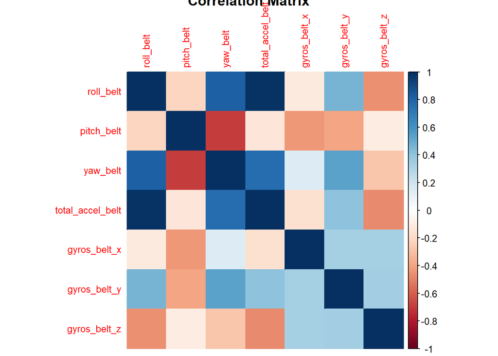

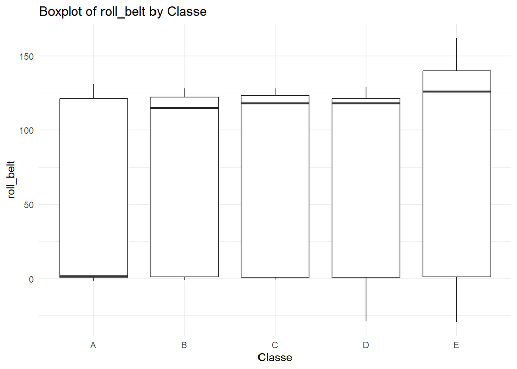